# Report on Senator voting activity and attendance, 2020/2021

**Summary**

**Voting days**

The initial analysis was a straightforward summary of the proportion of voting days on which a member of the 26th Seanad cast at least one vote. “Voting days” were defined as the number of sitting days (as votes can only take place on a sitting day) on which at least one vote was held. I decided to focus on voting days rather than total number of votes, as the clustering of votes on particular days meant that missing a single day could have a large effect on the number of votes missed (some voting days had up to 11 individual votes).

Figure 1 illustrates the proportion of the 48 voting days between June 29th 2020 and July 31st 2021 a given Senator voted on. This study window was chosen as attendance records used in subsequent analyses are only available up until 31st July 2021.

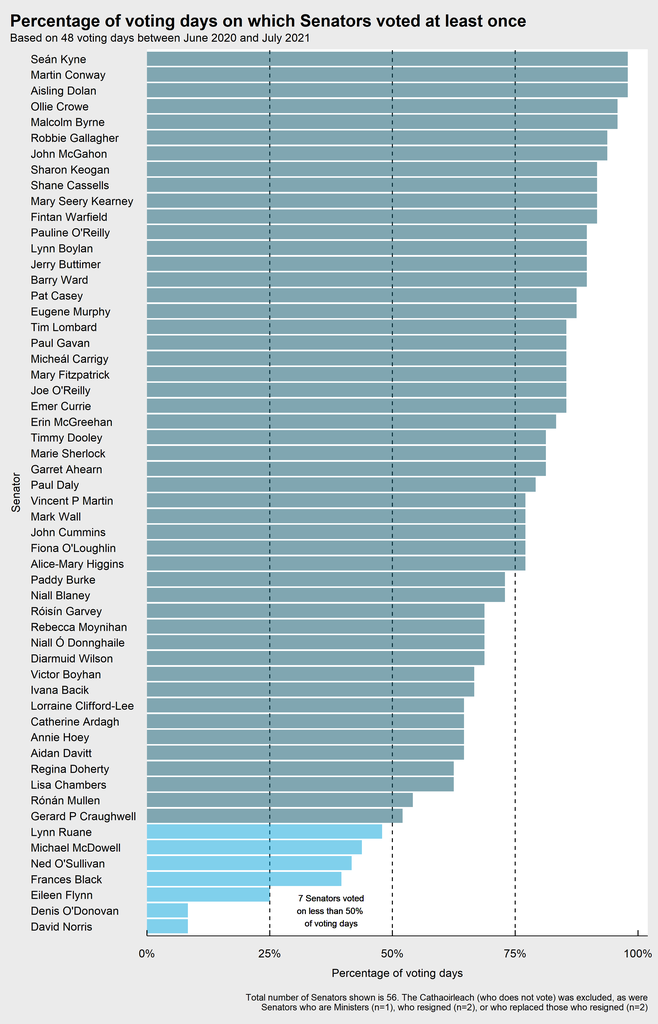

Summary of voting activity by Senator

Of interest, all six Senators elected by the NUI (Alice Mary Higgins, Michael McDowell, Rónán Mullen) and TCD (Ivana Bacik, David Norris, Lynn Ruane) University constituencies are in the bottom half of all Senators ranked by the number of voting days on which they voted.

From this graph, there seemed to be two obvious candidates for further investigation. Both David Norris and Denis O’Donovan cast a vote on only 4 of the 48 voting days in the study period.

**Days voted on vs days claimed as attended**

However, it could be that due to the ongoing pandemic, these Senators did not attend voting days (potentially due to ill health or travel difficulties) and so could not have voted.

In order to investigate whether this was the case, I scraped the voting days on which a Senators’ attendance at the Seanad was recorded for the purposes of the parliamentary allowance. This data is available in a PDF format from the Oireachtas website.

If Senators were not voting on voting days because they were not in attendance, we would expect that as the number of days on which Senators recorded their attendance increases, so to does the number of days on which they voted (this assumption is indicated by the line on the chart).

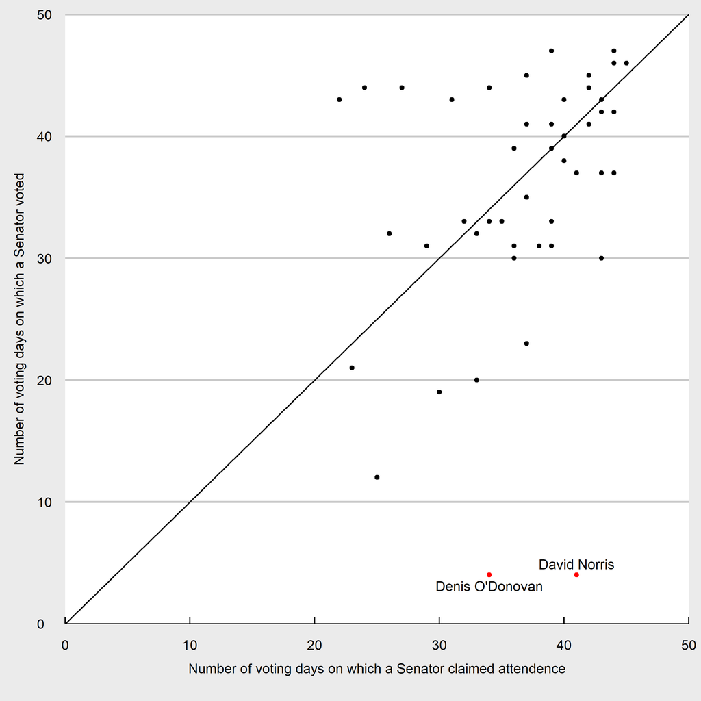

Number of voting days a Senator voted on versus number of voting days for which they claimed attendance. Line indicates a 1:1 relationship.

This expectation is largely true for the majority of Senators but is not applicable to our outliers of interest (denoted in red and with labels in the plot above). David Norris and Denis O’Donovan attended far fewer voting days versus the number of days on which they claimed attendance. This indicates that the finding from the initial barchart - that these two Senators attended very few votes - is not due to their absence from the Seanad.

So, David Norris and Denis O’Donovan are not voting on many of the days they are supposedly present in the Seanad. But political life is complicated - they may have been present on the voting day, but due to bad luck, have consistently missed the actual votes.

**Days with evidence of attendance vs days claimed as attended**

To examine this, my next step was to try and work out whether there was any record of Senators being present in the Seanad on days where they claimed to be in attendance. I defined evidence of attendance as either:

- A recorded vote
- A verbal contribution to the debate

Verbal contributions were obtained by scraping the official text for each sitting of the Seanad during my study window, and counting the number of times a Senator spoke.

This data on verbal contributions, combined with the voting data presented in the section above, allowed me to plot the number of days on which a Senator claimed they were present against the number of days for which there was evidence for them actually being present.

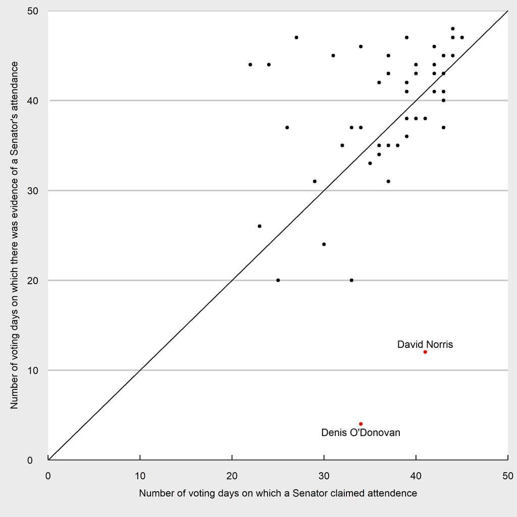

Number of voting days with evidence of attendance (vote/contribution) vs number of voting days claimed as attended. Line indicates a 1:1 relationship.

On some (n=8) of the voting days on which David Norris did not vote, he made verbal contributions to the debate providing evidence of attendance. In contrast, Denis O’Donovan did not make any verbal contributions on days he claimed attendance for but did not vote on.